# 5 Classifying wings

[figure not shown]

In this quick lesson, we try to classify wings using the tools seen in the last lessons.

```julia
using MetricSpaces
using Images
using DataFrames
using GLMakie
using Ripserer, PersistenceDiagrams
import Plots
using ProgressMeter

using Clustering
import StatsPlots

using MultivariateStats
using Chain
using ImageFiltering
```

We prepare a dataframe with the files and classes of each image

```julia
ds = DataFrame();

for (root, dir, files) in walkdir("wings/")

    for file in files
        dc = Dict(:Classe => root |> basename, :Caminho => file, :Caminho_completo => joinpath(root, file))

        push!(ds, dc, cols = :union)
    end
end

ds;
```

```julia
ds_split = groupby(ds, :Classe) |> collect;
```

```julia
function plot_mosaic(s)
    mosaicview(
    [imresize(load(f), (150, 300)) for f ∈ s.Caminho_completo[1:min(end, 21)]]
    , ncol = 3
    ,fillvalue = RGB24(1)
    )
end;

f = ds.Caminho_completo[1]
```

```
"wings/Asilidae/Asilidae 11.png"
```

## 5.1 The dataset

The dataset consists of several images of 3 different species of insects:

### 5.1.1 Asilidae

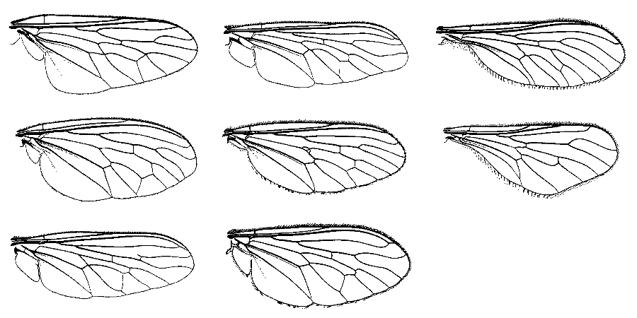

```julia
plot_mosaic(ds_split[1])
```

### 5.1.2 Ceratopogonidae

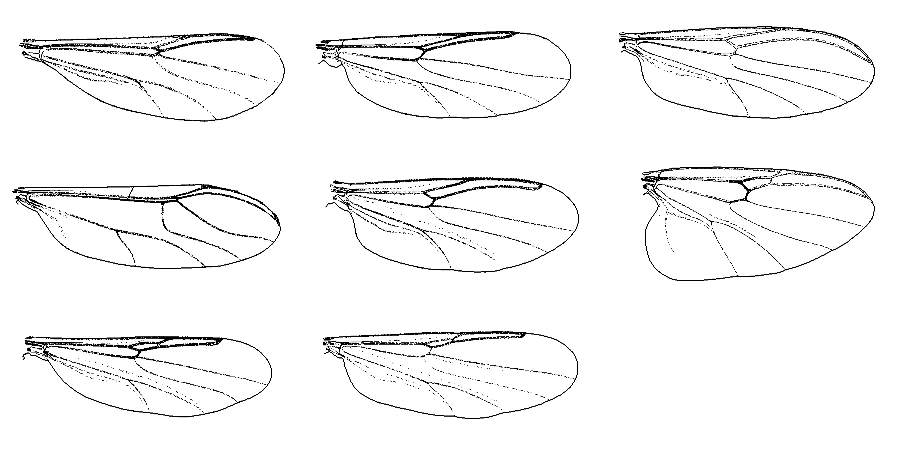

```julia
plot_mosaic(ds_split[2])
```

### 5.1.3 Tipulidae

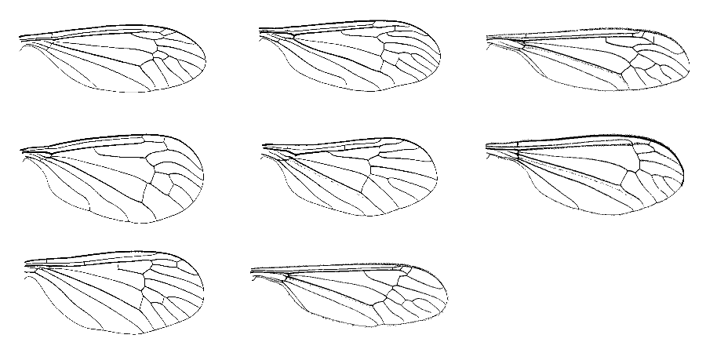

```julia
plot_mosaic(ds_split[3])
```

We load all images as matrices

```julia
images = [load(img) .|> Gray |> channelview for img ∈ ds.Caminho_completo];
```

We can see that the image is indeed correct:

```julia
images[1] |> image
```

[figure not shown]

## 5.2 Matrix to $\mathbb{R}^2$

As before, we need to transform each image in points of the plane.

```julia
function img_to_points(img)
    img2 = imfilter(img, Kernel.gaussian(1)) .|> float
    ids = findall(x -> x <= 0.8, img2)
    pts = getindex.(ids, [1 2])

    [ [ p[1], p[2] ] for p in eachrow(pts)] |> EuclideanSpace
end;
```

We convert each image to points

```julia
pts = img_to_points.(images);
```

and normalize the coordinates, since each image has a different size:

```julia
function normalize!(pts)
    a, b = extrema(pts .|> last)

    pts ./ (b - a)
end

wings = normalize!.(pts);
```

We can plot a scatter to check that it is indeed ok:

```julia
scatter(wings[1])
```

[figure not shown]

In order to apply the Vietoris-Rips filtration, we need to reduce the amount of points in each wing. The farthest point sample come in our rescue again!

```julia
wings_short = @showprogress map(wings) do w
    ids = farthest_points_sample(w, 400)
    w[ids]
end;
```

Now we calculate each barcode using the Vietoris-Rips filtration:

```julia
pds = @showprogress map(wings_short) do w
    ripserer(w, cutoff = 0.008)
end
```

```
24-element Vector{Vector{PersistenceDiagram}}:
 [400-element 0-dimensional PersistenceDiagram, 38-element 1-dimensional PersistenceDiagram]
 [400-element 0-dimensional PersistenceDiagram, 28-element 1-dimensional PersistenceDiagram]
 [400-element 0-dimensional PersistenceDiagram, 39-element 1-dimensional PersistenceDiagram]
 [400-element 0-dimensional PersistenceDiagram, 30-element 1-dimensional PersistenceDiagram]
 [400-element 0-dimensional PersistenceDiagram, 37-element 1-dimensional PersistenceDiagram]
 [400-element 0-dimensional PersistenceDiagram, 35-element 1-dimensional PersistenceDiagram]
 [400-element 0-dimensional PersistenceDiagram, 30-element 1-dimensional PersistenceDiagram]
 [400-element 0-dimensional PersistenceDiagram, 29-element 1-dimensional PersistenceDiagram]
 [400-element 0-dimensional PersistenceDiagram, 10-element 1-dimensional PersistenceDiagram]
 [400-element 0-dimensional PersistenceDiagram, 11-element 1-dimensional PersistenceDiagram]
 [400-element 0-dimensional PersistenceDiagram, 14-element 1-dimensional PersistenceDiagram]
 [400-element 0-dimensional PersistenceDiagram, 18-element 1-dimensional PersistenceDiagram]
 [400-element 0-dimensional PersistenceDiagram, 23-element 1-dimensional PersistenceDiagram]
 [400-element 0-dimensional PersistenceDiagram, 14-element 1-dimensional PersistenceDiagram]
 [400-element 0-dimensional PersistenceDiagram, 25-element 1-dimensional PersistenceDiagram]
 [400-element 0-dimensional PersistenceDiagram, 19-element 1-dimensional PersistenceDiagram]
 [400-element 0-dimensional PersistenceDiagram, 18-element 1-dimensional PersistenceDiagram]
 [400-element 0-dimensional PersistenceDiagram, 19-element 1-dimensional PersistenceDiagram]
 [400-element 0-dimensional PersistenceDiagram, 25-element 1-dimensional PersistenceDiagram]
 [400-element 0-dimensional PersistenceDiagram, 27-element 1-dimensional PersistenceDiagram]
 [400-element 0-dimensional PersistenceDiagram, 22-element 1-dimensional PersistenceDiagram]
 [400-element 0-dimensional PersistenceDiagram, 22-element 1-dimensional PersistenceDiagram]
 [400-element 0-dimensional PersistenceDiagram, 26-element 1-dimensional PersistenceDiagram]
 [400-element 0-dimensional PersistenceDiagram, 23-element 1-dimensional PersistenceDiagram]
```

We can now see the metric space

```julia
scatter(wings_short[1])
```

[figure not shown]

and the corresponding 1-dimensional persistente diagram

```julia
Plots.plot(pds[1][2])
```

[figure not shown]

Now we calculate the pairwise 1-dimensional bottleneck distance between each wing:

```julia
function barcode_to_distance(pds)
    n = length(pds)
    DB = zeros(n, n)

    @showprogress for i ∈ 1:n
        for j ∈ i:n
            if i == j
                DB[i, j] = 0
                continue
            end

            DB[i, j] = Bottleneck()(pds[i][2], pds[j][2])
            DB[j, i] = DB[i, j]
        end
    end

    DB
end
```

```
barcode_to_distance (generic function with 1 method)
```

```julia
DB = barcode_to_distance(pds)
```

```
24×24 Matrix{Float64}:
 0.0         0.0158869  0.0135061  …  0.0462039   0.0469204   0.0283849
 0.0158869   0.0        0.025868      0.0585658   0.0592823   0.0407468
 0.0135061   0.025868   0.0           0.0326978   0.0334143   0.020432
 0.00953908  0.0139792  0.0218124     0.0545102   0.0552267   0.0366912
 0.0235501   0.035912   0.0142476     0.0226538   0.0233703   0.0116482
 0.0230513   0.0182236  0.021989   …  0.0481824   0.0488989   0.0337146
 0.0487406   0.0611025  0.0352345     0.0121581   0.0141773   0.0203557
 0.014005    0.0263669  0.0123086     0.0321989   0.0329154   0.0143799
 0.0245204   0.0388475  0.0299852     0.0494071   0.0501236   0.0338243
 0.0341926   0.0285978  0.032716      0.0563412   0.05317     0.0411305
 0.0189494   0.0260279  0.0276124  …  0.0603102   0.0610267   0.0424912
 0.0276814   0.0249402  0.0411875     0.0738853   0.0746018   0.0560664
 0.0305476   0.0283709  0.0314908     0.0641885   0.064905    0.0463696
 0.02062     0.030228   0.023998      0.0552553   0.0559719   0.0374364
 0.0250578   0.0200642  0.0235812     0.0472065   0.0440353   0.0343454
 0.0683335   0.0559717  0.0818397  …  0.114537    0.115254    0.0967185
 0.0334725   0.0458344  0.0204434     0.0127314   0.0134479   0.0178701
 0.0211525   0.0335143  0.0116835     0.0284245   0.0312107   0.0190844
 0.0288523   0.0412142  0.0153462     0.0173516   0.0180681   0.0145953
 0.0518992   0.0642611  0.0383931     0.0139367   0.0114259   0.0235143
 0.0395003   0.0518622  0.0259942  …  0.0153055   0.0159943   0.0122653
 0.0462039   0.0585658  0.0326978     0.0         0.00844394  0.0213066
 0.0469204   0.0592823  0.0334143     0.00844394  0.0         0.0185355
 0.0283849   0.0407468  0.020432      0.0213066   0.0185355   0.0
```

and see if the classes are well separated:

```julia
function mds_plot(D)
    M = fit(MDS, D; distances = true, maxoutdim = 2)
    Y = predict(M)

    ds.Row = 1:nrow(ds)

    dfs = @chain ds begin
        groupby(:Classe)
        collect
    end

    fig = Figure();
    ax = Makie.Axis(fig[1,1])

    colors = cgrad(:tableau_10, 8, categorical = true)

    for (i, df) ∈ enumerate(dfs)
        scatter!(
            ax, Y[:, df.Row]
            , label = df.Classe[1], markersize = 15
            , color = colors[i]
            )
    end

    axislegend();
    fig

    fig
end;
```

```julia
mds_plot(DB)
```

[figure not shown]

## 5.3 Slicing it sideways

As we did with the hand-written digits dataset, we can do some sideways slicing on the wings.

```julia
set_value(x, value) = x < 0.99 ? value : x

function side_filtration(img, axis = 1, invert = false)

    img2 = imresize(img, (100, 200))
    m = imfilter(img2, Kernel.gaussian(0.4))
    # m = img .|> float
    m = set_value.(m, 0)
    # m |> image
    # m = img .|> float

    pts = img_to_points(m)

    a, b = if axis == 1
        extrema(pts .|> first)
        else
        extrema(pts .|> last)
    end

    for i ∈ a:b

        v = (b - i) / (b - a)

        if invert == true
            v = 1.0 - v
        end

        if axis == 1
            m[i, :] = set_value.(m[i, :], v)
        else
            m[:, i] = set_value.(m[:, i], v)
        end

    end

    m .|> float
end;
```

We can visualize the filtrations as follows:

```julia
img = images[5]
img2 = side_filtration(img, 1)
heatmap(img2)
```

[figure not shown]

```julia
img2 = side_filtration(img, 2)
heatmap(img2)
```

[figure not shown]

```julia
img2 = side_filtration(img, 1, true)
heatmap(img2)
```

[figure not shown]

```julia
img2 = side_filtration(img, 2, true)
heatmap(img2)
```

[figure not shown]

And calculate each barcode:

```julia
pds_x = @showprogress map(images) do img
    img2 = side_filtration(img)
    bc = ripserer(Cubical(img2), cutoff = 0.1)
end

pds_y = @showprogress map(images) do img
    img2 = side_filtration(img, 2)
    ripserer(Cubical(img2), cutoff = 0.1)
end

pds_x2 = @showprogress map(images) do img
    img2 = side_filtration(img, 1, true)
    ripserer(Cubical(img2), cutoff = 0.1)
end

pds_y2 = @showprogress map(images) do img
    img2 = side_filtration(img, 2, true)
    ripserer(Cubical(img2), cutoff = 0.1)
end
```

```
24-element Vector{Vector{PersistenceDiagram}}:
 [6-element 0-dimensional PersistenceDiagram, 17-element 1-dimensional PersistenceDiagram]
 [3-element 0-dimensional PersistenceDiagram, 21-element 1-dimensional PersistenceDiagram]
 [3-element 0-dimensional PersistenceDiagram, 13-element 1-dimensional PersistenceDiagram]
 [2-element 0-dimensional PersistenceDiagram, 20-element 1-dimensional PersistenceDiagram]
 [2-element 0-dimensional PersistenceDiagram, 16-element 1-dimensional PersistenceDiagram]
 [4-element 0-dimensional PersistenceDiagram, 18-element 1-dimensional PersistenceDiagram]
 [3-element 0-dimensional PersistenceDiagram, 21-element 1-dimensional PersistenceDiagram]
 [5-element 0-dimensional PersistenceDiagram, 21-element 1-dimensional PersistenceDiagram]
 [10-element 0-dimensional PersistenceDiagram, 40-element 1-dimensional PersistenceDiagram]
 [4-element 0-dimensional PersistenceDiagram, 17-element 1-dimensional PersistenceDiagram]
 [21-element 0-dimensional PersistenceDiagram, 18-element 1-dimensional PersistenceDiagram]
 [7-element 0-dimensional PersistenceDiagram, 15-element 1-dimensional PersistenceDiagram]
 [22-element 0-dimensional PersistenceDiagram, 21-element 1-dimensional PersistenceDiagram]
 [39-element 0-dimensional PersistenceDiagram, 12-element 1-dimensional PersistenceDiagram]
 [8-element 0-dimensional PersistenceDiagram, 15-element 1-dimensional PersistenceDiagram]
 [19-element 0-dimensional PersistenceDiagram, 13-element 1-dimensional PersistenceDiagram]
 [26-element 0-dimensional PersistenceDiagram, 10-element 1-dimensional PersistenceDiagram]
 [36-element 0-dimensional PersistenceDiagram, 11-element 1-dimensional PersistenceDiagram]
 [35-element 0-dimensional PersistenceDiagram, 6-element 1-dimensional PersistenceDiagram]
 [23-element 0-dimensional PersistenceDiagram, 18-element 1-dimensional PersistenceDiagram]
 [38-element 0-dimensional PersistenceDiagram, 14-element 1-dimensional PersistenceDiagram]
 [29-element 0-dimensional PersistenceDiagram, 9-element 1-dimensional PersistenceDiagram]
 [26-element 0-dimensional PersistenceDiagram, 5-element 1-dimensional PersistenceDiagram]
 [17-element 0-dimensional PersistenceDiagram, 16-element 1-dimensional PersistenceDiagram]
```

```julia
barcode(pds_x[5])
```

[figure not shown]

```julia
barcode(pds_y[5])
```

[figure not shown]

```julia
barcode(pds_x2[5])
```

[figure not shown]

```julia
barcode(pds_y2[5])
```

[figure not shown]

Let’s see way some figures have so many generators in dimension 1:

```julia
img = images[9]
img2 = side_filtration(img, 2, true)
heatmap(img2)
```

[figure not shown]

```julia
barcode(pds_y2[9])
```

[figure not shown]

The respective distance matrices are obtained with

```julia
DB_x = barcode_to_distance(pds_x)
DB_y = barcode_to_distance(pds_y)
DB_x2 = barcode_to_distance(pds_x2)
DB_y2 = barcode_to_distance(pds_y2)
```

```
24×24 Matrix{Float64}:
 0.0       0.325713  0.298343  0.164898  …  0.502762  0.612723  0.289092
 0.325713  0.0       0.380486  0.30512      0.599516  0.850059  0.316092
 0.298343  0.380486  0.0       0.227273     0.472488  0.635195  0.289641
 0.164898  0.30512   0.227273  0.0          0.465906  0.58974   0.278277
 0.269424  0.324795  0.28      0.248831     0.523943  0.791427  0.282226
 0.236258  0.381064  0.149272  0.133401  …  0.490336  0.653043  0.376954
 0.337017  0.247476  0.491706  0.293634     0.552486  0.813468  0.364641
 0.357143  0.214901  0.541667  0.326569     0.592159  0.773393  0.357143
 0.630172  0.580911  0.675477  0.602126     0.734369  0.768504  0.640938
 0.216896  0.497411  0.243819  0.196304     0.441745  0.735056  0.460388
 0.30455   0.252874  0.535287  0.324666  …  0.612982  0.82798   0.340557
 0.18034   0.333329  0.398941  0.252595     0.60662   0.704994  0.186046
 0.386805  0.312664  0.62529   0.451256     0.800758  0.85196   0.436765
 0.337017  0.482759  0.102273  0.232538     0.505535  0.610378  0.313947
 0.243924  0.333329  0.468204  0.269936     0.699314  0.762496  0.188937
 0.310581  0.362069  0.340765  0.289988  …  0.594937  0.835443  0.284884
 0.414365  0.573856  0.448857  0.363636     0.463877  0.645959  0.589754
 0.370159  0.482759  0.357955  0.329545     0.756637  0.873414  0.456036
 0.558401  0.835113  0.573447  0.545455     0.484143  0.65033   0.79324
 0.387342  0.317418  0.679487  0.491404     0.772375  0.820506  0.410405
 0.318275  0.344828  0.25791   0.297683  …  0.633987  0.841502  0.238372
 0.502762  0.599516  0.472488  0.465906     0.0       0.561036  0.744185
 0.612723  0.850059  0.635195  0.58974      0.561036  0.0       0.804219
 0.289092  0.316092  0.289641  0.278277     0.744185  0.804219  0.0
```

And we can see that none of the tools we used before can separate well the classes:

```julia
mds_plot(DB)
```

[figure not shown]

```julia
mds_plot(DB_x)
```

[figure not shown]

```julia
mds_plot(DB_y)
```

[figure not shown]

```julia
mds_plot(DB_x2)
```

[figure not shown]

```julia
mds_plot(DB_y2)
```

[figure not shown]

Even if we sum all these distances, we still can’t cluster correctly any class:

```julia
DB_final = zero(DB)

for d in [DB, DB_x, DB_y, DB_x2, DB_y2]
    DB_final = DB_final + (d ./ maximum(d))
end
```

```julia
mds_plot(DB_final)
```

[figure not shown]